# Medições referentes à métrica do tempo de resposta.

Grupo: Jobson Lucas Dias, José Benardi Nunes, Rafael Albuquerque

# Arquivos aqui avaliados

Neste arquivo, iremos comparar os dados das medições referentes aos tempos de respostas(representados por LogTIME) obtidos para os fatores(operação de add e remover) e níveis escolhidos(100 e 250 000 caracteres; poucos e muitos usuários).

# A estratégia utilizada:

Como a api Java utilizada usa como base para o cálculo dos milissegundos a meia noite de janeiro de 1970 UTC, e portanto, o tempo em milissegundos dará um valor muito grande, não é tão útil colocarmos no gráfico os valores deles em si; é mais adequado, no entanto, colocarmos o valor da diferença, que também está medida em milissegundos.

# Gráficos das leituras ao longo do tempo para todos os logs

## Gráfico(log01) para operação de add com poucos usuários e um arquivo de 100 caracteres.

[interactive chart not shown]

## Gráfico(log02) para operação de del com poucos usuários e um arquivo de 100 caracteres.

[interactive chart not shown]

## Gráfico(log03) para operação de add com poucos usuários e um arquivo de 250000 caracteres.

[interactive chart not shown]

## Gráfico(log04) para operação de del com poucos usuários e um arquivo de 250000 caracteres.

[interactive chart not shown]

## Gráfico(log05) para operação de add com muitos usuários e um arquivo de 100 caracteres.

[interactive chart not shown]

## Gráfico(log06) para operação de del com muitos usuários e um arquivo de 100 caracteres.

[interactive chart not shown]

## Gráfico(log07) para operação de add com muitos usuários e um arquivo de 250000 caracteres.

[interactive chart not shown]

## Gráfico(log08) para operação de del com muitos usuários e um arquivo de 250000 caracteres.

[interactive chart not shown]

# Análises

Para os casos em que notamos outliers, talvez fosse mais apropriado utilizar a mediana como medida estatística ao invés da média, tendo em vista que aquela é uma medida robusta, isto é, não é afetada por outliers, enquanto que está é. Além disso, como o desvio padrão e a variância fazendo uso da média e levam em conta todos outliers, temos que eles também serão bastante afetados pela presença desses valores.

## Análise para operação do log1Time:

Notamos que, no gráfico referente ao log1TIME, existem indícios de alguns outliers, como na leitura 41 (cujo valor é 1131 milissegundos), pois ela se distanciou muito das demais em termos de diferença em milissegundos. Vamos fazer uma visualização de um box-plot para essa medição de modo a constarmos se, de fato, existem outliers.

[figure not shown]

### Conclusão

Nossa asserção sobre a existência de outliers estava correta e foi confirmada pelo boxplot acima. Existem, ao todo, 3 outliers.

## Análise para operação de log2Time:

Notamos que, no gráfico referente ao log2TIME, existem indícios de alguns outliers, como na leitura 39, pois ela se distanciou de maneira singular com relação às demais em termos de diferença em milissegundos. Vamos fazer uma visualização de um box-plot para essa medição de modo a constarmos se, de fato, existe algum outlier.

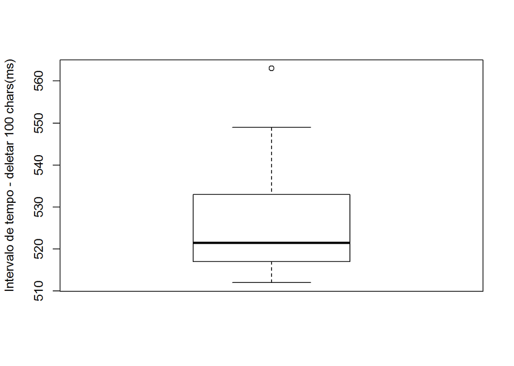

### Conclusão

De fato, nossa hipótese sobre a presença de outlier estava correta e foi confirmada pelo boxplot acima, pois é possível notar a existência de 1 outlier.

## Análise para operação log3Time:

Notamos que, no gráfico referente ao log3TIME, existem indícios de alguns outliers, como na leitura 21(792), pois ela se distanciou de maneira singular com relação às demais em termos de diferença em milissegundos. Vamos fazer uma visualização de um box-plot para essa medição de modo a constarmos se, de fato, existe algum outlier.

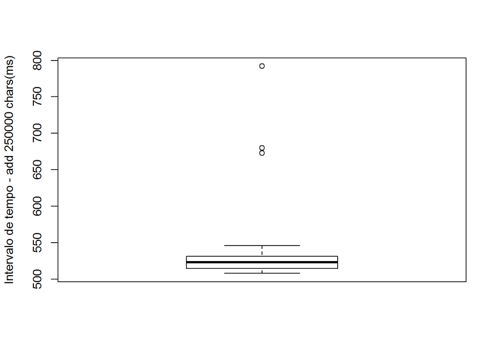

### Conclusão

De fato, nossa hipótese sobre a presença de outlier estava correta e foi confirmada pelo boxplot acima, pois notamos a existência de 3 outliers.

## Análise para operação log4Time:

Não notamos no gráfico referente ao log4TIME quaisquer indícios de algum outliers.Para validarmos nossa hipótese, vamos fazer uma visualização de um box-plot para essa medição de modo a constarmos se, de fato, não existe algum outlier.

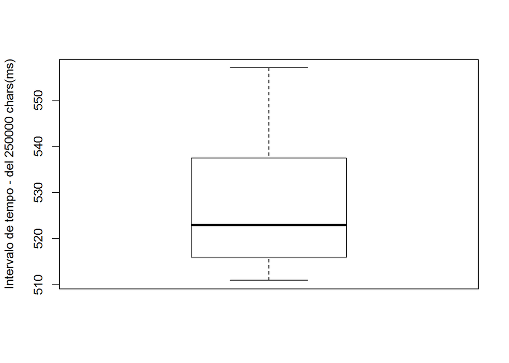

### Conclusão

De fato, nossa hipótese sobre ausência de outliers estava correta e foi confirmada pelo boxplot acima.

## Análise para operação log5Time:

Notamos que, no gráfico referente ao log5TIME, existem indícios de alguns outliers, como na leitura 41(684), pois ela se distanciou de maneira singular com relação às demais em termos de diferença em milissegundos. Vamos fazer uma visualização de um box-plot para essa medição de modo a constarmos se, de fato, existe algum outlier.

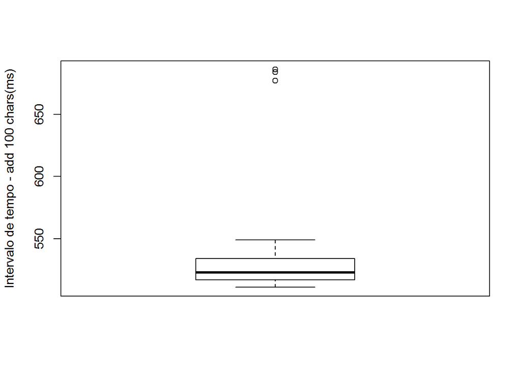

## Conclusão

De fato, nossa hipótese sobre a presença de outlier estava correta e foi confirmada pelo boxplot acima.Podemos ver no boxplot acima a existência de 3 outliers.

## Análise para operação log6Time:

Aqui também não notamos no gráfico referente ao log6TIME quaisquer indícios de existência de outliers. Para validarmos nossa hipótese, vamos fazer uma visualização de um box-plot para essa medição de modo a constarmos se, de fato, não existe algum outlier.

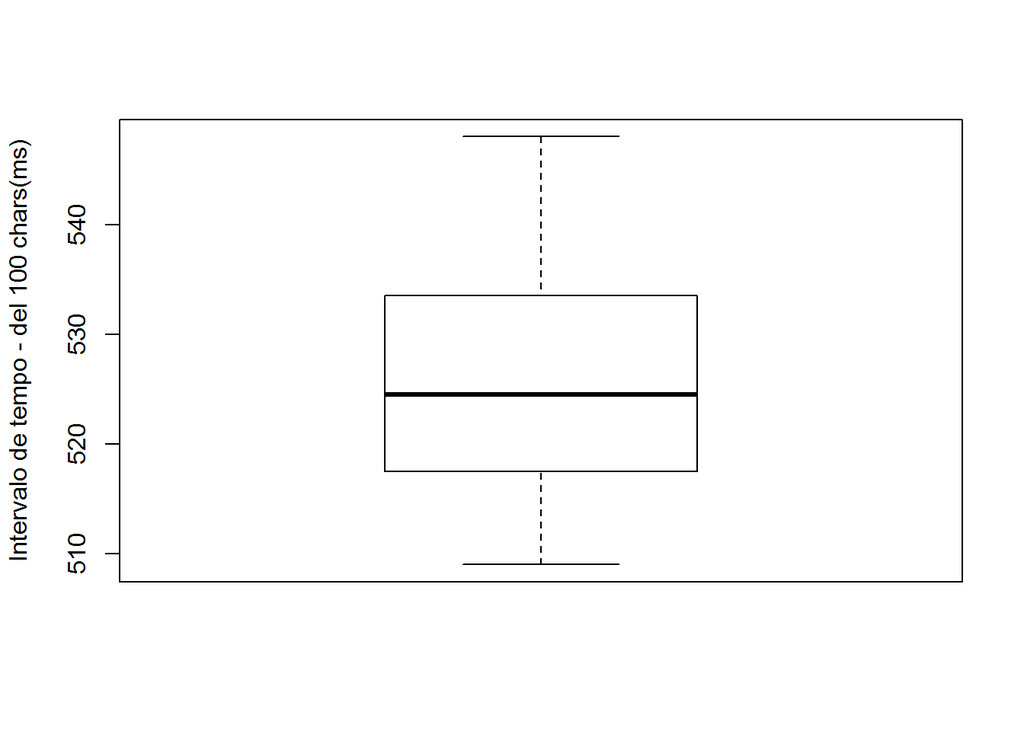

## Conclusão

De fato, nossa hipótese sobre inexistência de outliers para essa medição estava correta e foi confirmada pelo boxplot acima.

## Análise para operação log7Time:

Notamos que, no gráfico referente ao log7TIME, existem indícios de alguns outliers, como na leitura 41(700), pois ela se distanciou de maneira singular com relação às demais em termos de diferença em milissegundos. Vamos fazer uma visualização de um box-plot para essa medição de modo a constarmos se, de fato, existe algum outlier.

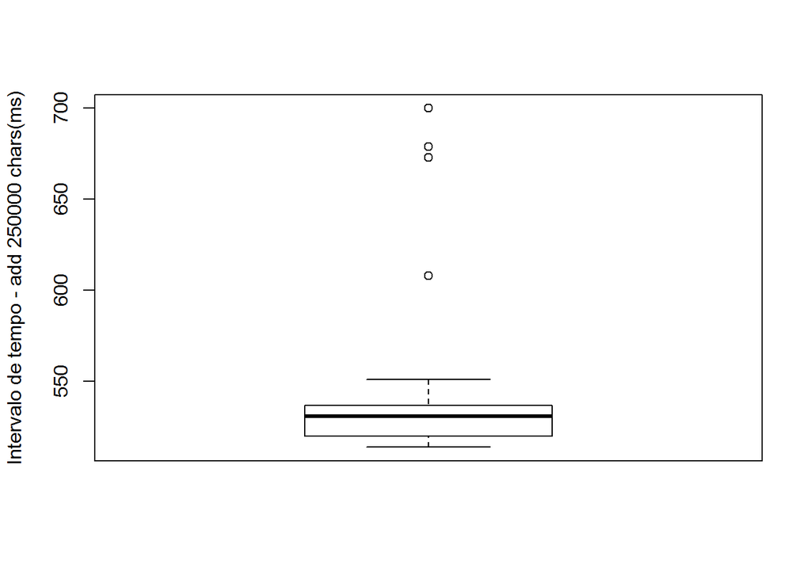

## Conclusão

De fato, nossa hipótese sobre a presença de outlier estava correta e foi confirmada pelo boxplot acima. Foram identificados 4 outliers.

## Análise para operação log8Time:

Outra vez não notamos no gráfico referente ao log8TIME quaisquer indícios de existência de outliers. Para validarmos nossa hipótese, vamos fazer uma visualização de um box-plot para essa medição de modo a constarmos se, de fato, não existe algum outlier.

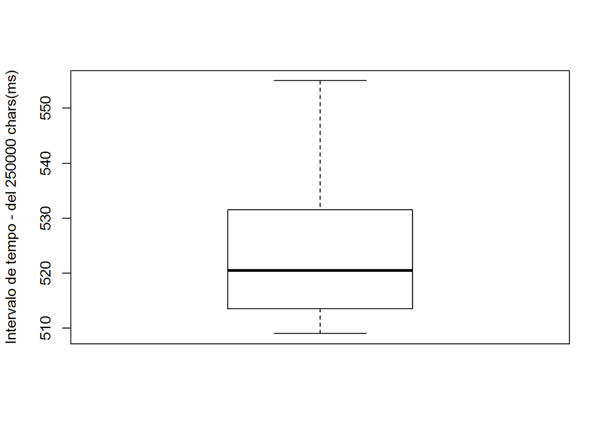

## Conclusão

Podemos concluir que nossa hipótese sobre inexistência de outliers para essa medição estava correta e foi confirmada pelo boxplot acima.

# Tratamento estatístico

Abaixo veremos a média, mediana, e desvio padrão, além do intervalo de confiança(i.c.) com 95% de confiança(alfa = 0,05) para os dados das medições realizadas. Também vamos avaliar o grau de representatividade da média através do coeficiente de variação(cv), que também server para nos indicar a homogeneidade (se os valores estão ao redor da média), a precisão dos dados e a variabilidade com relação à média (quanto o conjunto se afasta da média). Como resultado direto, temos que quanto menor o c.v., maior a homogeneidade e a precisão do conjunto de dados. Além disso, se o valor do cv for menor que 50%, então a média é dita representativa; não, caso contrário.

## Medidas estatísticas para log01Time

```
## [1] "o valor da média para as distâncias para o log01TIME é: 538.966667"
```

```
## [1] "o valor da mediana para as distâncias para o log01TIME é: 522.000000"
```

```
## [1] "o valor da variância para as distâncias para o log01TIME é: 7174.371751"
```

```
## [1] "o valor do desvio padrão para as distâncias para o log01TIME é: 84.701663"
```

```
## [1] "o valor do coeficiente de variação para as distâncias para o log01TIME é: 15.715566%"
```

```
## [1] "Com 95% de confiança, o intervalo que compreende o verdadeiro valor da média está entre 517.534583 e 560.398751."
```

## Interpretação:

Apesar do outliers, vemos que nossa média ainda permanece significativa, temos um coeficiente de variação de menos de 50% (aproximadamente 15.71%). Poderíamos classificar esse coeficiente de variação como tendo uma dispersão média e relativamente homogênea, além de uma boa precisão. Em outras palavras, tivemos que apenas 15.71% dos valores se afastam da média(os outros estão ao redor/bem próximos dela). Também temos que o intervalo de confiança foi relativamente extenso, o que limita um pouco nossa capacidade de ter um conhecimento sobre o valor real da média de maneira significativa. Talvez isso se deva ao número de experimentações que foi de apenas 60 para cada operação. Sobre as medidas de dispersão: como era de se esperar, a variância resultou em um valor assustadoramente grande e o desvio padrão foi expressivo. Isso é consequência direta da presença dos outliers.

# Medidas estatísticas para log02Time

```
## [1] "o valor da média para as distâncias log02Time é: 525.900000"
```

```
## [1] "o valor da mediana para as distâncias log02Time é: 521.500000"
```

```
## [1] "o valor da variância para as distâncias log02Time é: 134.905085"
```

```
## [1] "o valor do desvio padrão para as distâncias log02Time é: 11.614865"
```

```
## [1] "o valor do coeficiente de variação para as distâncias log02Time é: 2.208569%"
```

```
## [1] "Com 95% de confiança, o intervalo que compreende o verdadeiro valor da média está entre 522.961088 e 528.838912."
```

## Interpretação:

Surpreendentemente, vemos que nosso cv para média do log02TIME(apenas 2.2%) foi ainda menor, o que indica, por exemplo, que a homogeneidade dos resultados aqui é maior do que a obtida, por exemplo, no log01TIME e que a variabilidade com relação à média foi baixíssima(a esmagadora maioria dos valores estão ao redor da média). Como resultado, temos que nossos dados possuem baixa dipersão, ótima precisão e alta homogeneidade. Também temos que a média é significativa. Obtivemos um intervalo de confiança aqui, digamos, mais significativo, pelo fato dele ser muito menos extenso que para operação de add vista anteriormente. Também obtivemos que nossa variância não ficou tão grande se compararmos com a variância obtida para o log01TIME. O mesmo comentário poderia ser feito sobre o desvio padrão.

## Medidas estatísticas para log03Time

```
## [1] "o valor da média para as distâncias log03Time é: 533.250000"
```

```
## [1] "o valor da mediana para as distâncias log03Time é: 523.500000"
```

```
## [1] "o valor da variância para as distâncias log03Time é: 2015.750000"
```

```
## [1] "o valor do desvio padrão para as distâncias log03Time é: 44.897105"
```

```
## [1] "o valor do coeficiente de variação para as distâncias log03Time é: 8.419523%"
```

```
## [1] "Com 95% de confiança, o intervalo que compreende o verdadeiro valor da média está entre 521.889674 e 544.610326."
```

## Interpretação:

Surpreendentemente, vemos que nosso cv para média do log03TIME(apenas 8.42%) foi também menor que o do log01, o que indica, por exemplo, que a homogeneidade dos resultados aqui é maior que para operação de add com 100 chars e que a variabilidade com relação à média foi baixa(a imensa maioria dos valores estão ao redor da média). Como resultado, temos que nossos dados possuem baixa dipersão, ótima precisão e alta homogeneidade. Também temos que a média é significativa(8.42% < 50%). Obtivemos um intervalo de confiança aqui, digamos, mais significativo, pelo fato dele ser menos extenso que o obtido para o log01TIME, vistO anteriormente. Também em relação ao log01TIME obtivemos a variância com um valor grande, devido à existência de outliers, embora com um valor menor. O mesmo comentário poderia ser feito sobre o desvio padrão.

# Medidas estatísticas para log04Time

```
## [1] "o valor da média para as distâncias log04Time é: 527.016667"
```

```
## [1] "o valor da mediana para as distâncias log04Time é: 523.000000"
```

```
## [1] "o valor da variância para as distâncias log04Time é: 146.525141"
```

```
## [1] "o valor do desvio padrão para as distâncias log04Time é: 12.104757"
```

```
## [1] "o valor do coeficiente de variação para as distâncias log04Time é: 2.296845%"
```

```
## [1] "Com 95% de confiança, o intervalo que compreende o verdadeiro valor da média está entre 523.953797 e 530.079536."
```

## Interpretação:

Surpreendentemente, vemos que nosso cv para média do log04TIME(apenas ~2.3%) foi 0.1 décimos maior, o que indica, por exemplo, que a homogeneidade dos resultados aqui é relativamente menor do que a obtida, por exemplo, no log02TIME e que a variabilidade com relação à média foi baixíssima(a esmagadora maioria dos valores estão ao redor da média). Como resultado, temos que nossos dados possuem baixa dipersão, ótima precisão e alta homogeneidade. Também temos que a média é significativa. Com relação ao intervalo de confiança, obtivemos um resultado aqui, digamos, menos significativo, pelo fato dele ser um pouco mais extenso do que o obtido no log02TIME. Já a variância foi maior se compararmos com a variância obtida para o log02TIME. O mesmo comentário poderia ser feito sobre o desvio padrão. Os resultados opostos poderiam ser apontados se comparássemos com o log03TIME: o CV para o log04TIME é menor, indicando mais homogeneidade e precisão; também temos um intervalo de confiança menos extenso (portanto, mais significativo); medidas de dispersão (variância e desvio padrão) também menores.

## Medidas estatísticas para log05Time

```
## [1] "o valor da média para as distâncias para o log05TIME é: 532.733333"
```

```
## [1] "o valor da mediana para as distâncias para o log05TIME é: 523.000000"
```

```
## [1] "o valor da variância para as distâncias para o log05TIME é: 1281.080226"
```

```
## [1] "o valor do desvio padrão para as distâncias para o log05TIME é: 35.792181"
```

```
## [1] "o valor do coeficiente de variação para as distâncias para o log05TIME é: 6.718592%"
```

```
## [1] "Com 95% de confiança, o intervalo que compreende o verdadeiro valor da média está entre 523.676828 e 541.789838."
```

## Interpretação:

Vemos que nosso cv para média do log05TIME(apenas 6.72%) foi menor que o obtido, por exemplo, no log01TIME, o que indica que a homogeneidade dos resultados aqui é maior e que a variabilidade com relação à média foi menor, sendo também considerada baixa(a maioria dos valores estão ao redor da média). Como resultado, temos que nossos dados possuem baixa dipersão, boa precisão e alta homogeneidade. Também temos que a média é significativa. Obtivemos um intervalo de confiança aqui, digamos, mais significativo, pelo fato dele ser menos extenso que o do log01TIME. Também obtivemos que, apesar da existência de outliers, nossa variância não ficou tão grande se compararmos com a variância obtida para o log01TIME. O mesmo comentário poderia ser feito sobre o desvio padrão.

# Medidas estatísticas para log06Time

```
## [1] "o valor da média para as distâncias log06Time é: 525.833333"
```

```
## [1] "o valor da mediana para as distâncias log06Time é: 524.500000"
```

```
## [1] "o valor da variância para as distâncias log06Time é: 111.666667"
```

```
## [1] "o valor do desvio padrão para as distâncias log06Time é: 10.567245"
```

```
## [1] "o valor do coeficiente de variação para as distâncias log06Time é: 2.009619%"
```

```
## [1] "Com 95% de confiança, o intervalo que compreende o verdadeiro valor da média está entre 523.159501 e 528.507166."
```

## Interpretação:

Surpreendentemente, vemos que nosso cv para média do log06TIME(apenas ~2.0%) foi o menor cv obtido até agora, o que indica, por exemplo, que a homogeneidade dos resultados aqui é maior do que a obtida, por exemplo, no log02TIME(cv ~2.2%) e que a variabilidade com relação à média foi baixíssima(a esmagadora maioria dos valores estão ao redor da média). Como resultado, temos que nossos dados possuem baixa dipersão, ótima precisão e alta homogeneidade. Também temos que a média é significativa. Obtivemos um intervalo de confiança aqui, digamos, mais significativo, pelo fato dele ser menos extenso que o obtido para o log02TIME. Também obtivemos que nossa variância ficou menor, bem como o desvio padrão. Os resultados aqui obtidos são ainda melhores se comparássemos com o log05TIME: o CV para o log06TIME é menor, indicando mais homogeneidade e precisão; também temos um intervalo de confiança bastante menor(portanto, mais significativo); medidas de dispersão (variância e desvio padrão) bem menores.

## Medidas estatísticas para log07Time

```
## [1] "o valor da média para as distâncias para o log07TIME é: 538.583333"
```

```
## [1] "o valor da mediana para as distâncias para o log07TIME é: 531.000000"
```

```
## [1] "o valor da variância para as distâncias para o log07TIME é: 1326.213277"
```

```
## [1] "o valor do desvio padrão para as distâncias para o log07TIME é: 36.417211"
```

```
## [1] "o valor do coeficiente de variação para as distâncias para o log07TIME é: 6.761667%"
```

```
## [1] "Com 95% de confiança, o intervalo que compreende o verdadeiro valor da média está entre 529.368677 e 547.797990."
```

## Interpretação:

Vemos que nosso cv para média do log07TIME(apenas 6.76%) foi menor que o obtido, por exemplo, no log03TIME, o que indica que a homogeneidade dos resultados aqui é maior e que a variabilidade com relação à média foi menor, sendo também considerada baixa(a maioria dos valores estão ao redor da média). Como resultado, temos que nossos dados possuem baixa dipersão, boa precisão e alta homogeneidade. Também temos que a média é significativa. Obtivemos um intervalo de confiança aqui, digamos, mais significativo, pelo fato dele ser menos extenso que o do log03TIME. Também obtivemos variância e desvio padrão menores. Os resultados opostos poderiam ser apontados se comparássemos com o log05TIME: o CV para o log07TIME é maior, indicando menos homogeneidade e precisão; também temos um intervalo de confiança um pouco mais extenso (portanto, menos significativo); medidas de dispersão (variância e desvio padrão) também maiores.

# Medidas estatísticas para log08Time

```
## [1] "o valor da média para as distâncias log08Time é: 522.983333"
```

```
## [1] "o valor da mediana para as distâncias log08Time é: 520.500000"
```

```
## [1] "o valor da variância para as distâncias log08Time é: 120.694633"
```

```
## [1] "o valor do desvio padrão para as distâncias log08Time é: 10.986111"
```

```
## [1] "o valor do coeficiente de variação para as distâncias log08Time é: 2.100662%"
```

```
## [1] "Com 95% de confiança, o intervalo que compreende o verdadeiro valor da média está entre 520.203515 e 525.763152."
```

## Interpretação:

Nosso cv para média do log08TIME(apenas ~2.1%) foi menor que os obtidos para log07TIME E log04TIME, o que indica, por exemplo, que a homogeneidade dos resultados aqui é maior e que a variabilidade com relação à média foi baixíssima(a esmagadora maioria dos valores estão ao redor da média). Como resultado, temos que nossos dados possuem baixa dipersão, ótima precisão e alta homogeneidade. Também temos que a média é significativa. Obtivemos um intervalo de confiança aqui, digamos, mais significativo, pelo fato dele ser menos extenso que o obtido para o log07TIME e log04TIME. Também obtivemos que nossa variância ficou menor, bem como o desvio padrão. Os resultados aqui obtidos são inferiores um pouco se comparássemos com o log06TIME: o CV para o log06TIME é menor, indicando mais homogeneidade e precisão; também temos um intervalo de confiança ligeiramente menor(portanto, ligeiramente mais significativo); medidas de dispersão (variância e desvio padrão) um pouco menores.